# NCEI GHCN Extreme Value Analysis

# 1 Goal

A reference for the extRemes package can be found here

Gilleland, E., & Katz, R. (2016). extRemes 2.0: An Extreme Value Analysis Package in R. Journal of Statistical Software, 72(8), 1-39. doi:http://dx.doi.org/10.18637/jss.v072.i08 ( PDF Avaialble at https://www.jstatsoft.org/article/view/v072i08 )

# 2 Libraries

The following libraries are needed for this exercise.

Tidyverse Packages

- [tidyverse](https://www.tidyverse.org) : Set of commonly-used Data Science packages for R that it can install and load all at once. In the long-run you probably also want to install the tidyverse package suite anyway. For this exercise this will include…
  - [ggplot2](https://ggplot2.tidyverse.org) : Create Elegant Data Visualizations Using the Grammar of Graphics
  - [tibble](https://tibble.tidyverse.org) : Simple Data Frames
  - [tidyr](https://tidyr.tidyverse.org) : Tools for shepherding data in data frames.
  - [readr](https://readr.tidyverse.org) : Read Rectangular Text Data
  - [purr](https://purrr.tidyverse.org) : Functional Programming Tools
  - [dplyr](https://dplyr.tidyverse.org) : A grammar of data manipulation
  - [stringr](https://stringr.tidyverse.org) : Simple, Consistent Wrappers for Common String Operations
  - [forcats](https://forcats.tidyverse.org) : Tools for Working with Categorical Variables (Factors)
- [lubridate](https://lubridate.tidyverse.org) : Time and Date Management

Other Packages

- [rnoaa](https://www.rdocumentation.org/packages/rnoaa/) : Climate Data Online Services from NCEI
- extRemes : NCAR functions for performing extreme value analysis.
- [Jan Gleixner’s & Wouter van der Bijl’s custom GeomSplitViolin() code](https://stackoverflow.com/questions/35717353/split-violin-plot-with-ggplot2/45614547#45614547)

There are plots where you can see the shape of distributions side-by-side called [“violin plots”](https://en.wikipedia.org/wiki/Violin_plot). Some people like to a pair of distributons. This isn’t officially part of any current R library but it was desirable enough for a air of saints from Max Plank Institute and Stockholm University to write a piece of code to emulate it.

Source: [Stackoverflow](https://stackoverflow.com/questions/35717353/split-violin-plot-with-ggplot2/45614547#45614547)

```r
# Libraries

  # Tidyverse resources

  library(package = "tidyverse") # Multiple Tidyverse Resources
  library(package = "lubridate") # Date-Time Control
  library(package = "ggridges")  # Ridgeline plots with ggplot2


  # NOAA Libraries

  library(package = "rnoaa") # NCEI  Data Retrieval Package

  # NCAR Libraries

  library(package = "extRemes") # NCEI  Data Retrieval Package
```

# 3 Extracting Data

## 3.1. Pulling Climate Division

Here the user needs to identify a 4 digit climate division

```r
# User Selection

  # Climate Division Selection

  target_climate_zone = "3904"
```

## 3.2 Extracting nCLIMDIV data for Lookup Table Information

We also can pull the NCEI nCLIMDIV monthnly statistics for any US Climate Division. As with the LOCA data it is also kept on our servers at SD Mines.

We also need this dataset because it contains helpful metadata for the dataset

```r
# Pulling nCLIMDIV for Zone Lookup Tables

  nCLIMDIV_LUT_URL = "http://kyrill.ias.sdsmt.edu:8080/thredds/fileServer/CLASS_Examples/nCLIMDIV_LUT.csv"

  state_zone_lut = read_csv(file = url(nCLIMDIV_LUT_URL))
  remove(nCLIMDIV_LUT_URL)

  #
  # Create Pulldown Look-up-Tables
  #

  state_zone_lut =  state_zone_lut %>%
      mutate(State_Code    = substring(text  = Full_Zone_Code,
                                       first = 1,
                                       last  = 2),
             SubState_Code = substring(text  = Full_Zone_Code,
                                       first = 3,
                                       last  = 4)) %>%
      mutate(Zone_Name_and_Code = str_c(SubState_Code,
                                        Zone_Name,
                                        sep = " : "),
             Zones_Per_State    = max(SubState_Code) ) %>%
      unique()
```

## 3.3 Extracting LOCA data

The LOCA dsata for this script is stored on a THREDDS server at SD Mines. Each NCEI climate division has its own separate file They can be accessed fairly easily with R using the [url()](https://www.rdocumentation.org/packages/base/versions/3.6.0/topics/connections) command.

```r
# LOCA Data Extraction from SD Mines Thredds Server

  # URL Information

  root_LOCA_URL = "http://kyrill.ias.sdsmt.edu:8080/thredds/fileServer/LOCA_NGP/climate_divisions/"

  loca_filename = str_c("NGP_LOCA_nCLIMDIV_",
                        target_climate_zone,
                        ".RData",
                        sep = "")

  LOCA_URL = str_c(root_LOCA_URL,
                   loca_filename,
                   sep = "")

  load(file    = url(LOCA_URL),
       verbose = TRUE)
```

```
Loading objects:
  loca_daily
```

```r
  remove(LOCA_URL)

  Ensembles = unique(loca_daily$Ensemble)
  Scenarios = unique(loca_daily$Scenario)
```

# 4 Exteme Event Analysis

## 4.1 Period Selection

Here we are going to select a “control” period representing a period before the “point of divergence” in our alternative histories (the RCP 4.5 and RCP 8.5)

```r
# Select Periods

  # "Historical" Period

  reference_period_start = 1981
  reference_period_end   = 2005

  # "Future" Period

  future_period_start    = 2036
  future_period_end      = 2065
```

We are extractring the period data here.

(Also we are editing the names of the scenario’s to include the period years)

```r
# Period Extraction (using the zone maximum daily event)

  loca_daily = loca_daily %>%
    mutate(Center_of_Month = as.Date(str_c(year(Time),
                                           month(Time),
                                           "15",
                                           sep="-"),
                                     tryFormats = c("%Y-%m-%d")))

  loca_histo = loca_daily %>%
    filter((year(Time) >= reference_period_start) &
           (year(Time) <= reference_period_end)   &
           (Percentile == "P100")                 ) %>%
    mutate(Scenario = str_c(Scenario,
                            " (",
                            reference_period_start,
                            "-",
                            reference_period_end,
                            ")",
                            sep = ""))

  loca_futr = loca_daily %>%
    filter((year(Time) >= future_period_start)    &
           (year(Time) <= future_period_end)      &
           (Percentile == "P100")                 )  %>%
    mutate(Scenario = str_c(Scenario,
                            " (",
                            future_period_start,
                            "-",
                            future_period_end,
                            ")",
                            sep = ""))

  loca_periods = rbind(loca_histo,
                       loca_futr)

  remove(loca_histo)
  remove(loca_futr)

  Scenarios = unique(loca_periods$Scenario)

  loca_location_data = state_zone_lut %>%
    filter(Full_Zone_Code == target_climate_zone)

  State_Name    = unique(loca_location_data$State_Name)
  Division_Name = unique(loca_location_data$Zone_Name)
```

## 4.2 Calculating Yearly Maxima

This is mostly for illustrative purposes because we are using the daily data for our return periods.

Here we are taking the extreme maximum rainfall for each year.

```r
# Yearly Maximum

  loca_period_extremes = loca_periods %>%
    group_by(Year = year(Time),
             Ensemble,
             Scenario) %>%
    summarize(tasmax_max_ann = max(tasmax),
              tasmin_min_ann = min(tasmax),
              pr_max_ann     = max(pr))
```

The plot below shows a collective shape of all of our yearly maximum rainfal distributions

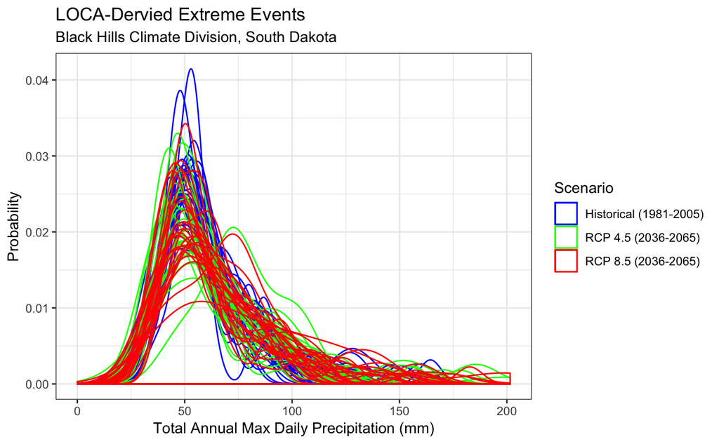

```r
loca_period_histo = loca_period_extremes %>%
                      filter(str_detect(Scenario, "Historical"))

loca_period_rcp85 = loca_period_extremes %>%
                      filter(str_detect(Scenario, "8.5"))

loca_period_rcp45 = loca_period_extremes %>%
                      filter(str_detect(Scenario, "4.5"))

ggplot(data = loca_period_extremes) +
  aes(x     = pr_max_ann,
      group = Ensemble,
      color = Scenario) +

  theme_bw() +

  ggtitle(label    = "LOCA-Dervied Extreme Events",
          subtitle = str_c(Division_Name,
                           " Climate Division, ",
                           State_Name,
                           sep = "")) +

  scale_color_manual(values = c("blue",       "green",  "red")) +

  ylab(label = "Probability")  +

  xlab(label = "Total Annual Max Daily Precipitation (mm)")  +

  xlim(0, max(loca_period_extremes$pr_max_ann)) +

  geom_density(data  = loca_period_histo,
               alpha = 0.1) +
  geom_density(data  = loca_period_rcp45,
               alpha = 0.1) +

  geom_density(data  = loca_period_rcp85,
               alpha = 0.1)
```

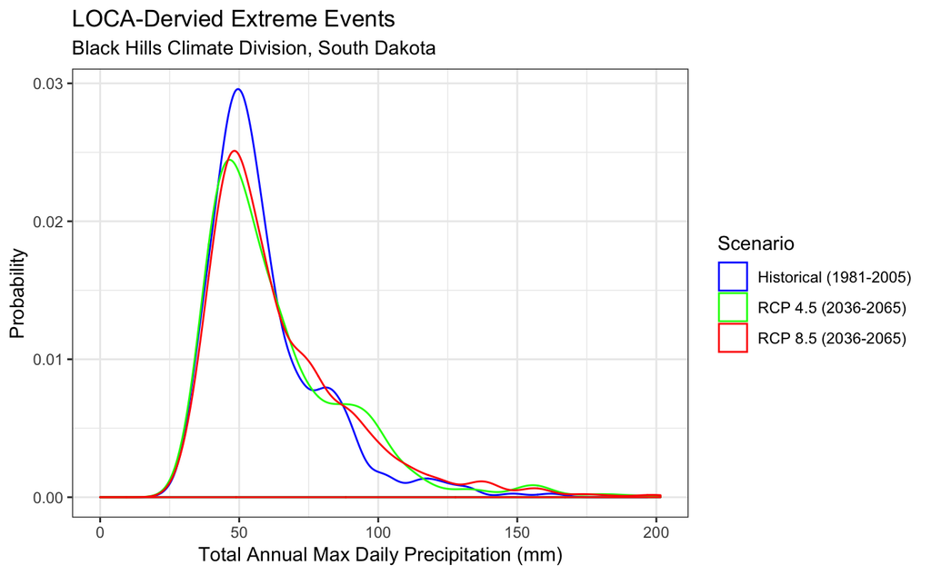

```r
ggplot(data = loca_period_extremes) +
  aes(x     = pr_max_ann,
      color = Scenario) +

  theme_bw() +

  ggtitle(label    = "LOCA-Dervied Extreme Events",
          subtitle = str_c(Division_Name,
                           " Climate Division, ",
                           State_Name,
                           sep = "")) +

  scale_color_manual(values = c("blue",
                                "green",
                                "red")) +

  ylab(label = "Probability")  +

  xlab(label = "Total Annual Max Daily Precipitation (mm)")  +

  xlim(0, max(loca_period_extremes$pr_max_ann)) +

  geom_density()
```

```r
NA
NA
NA
```

# 5 General Pareto Distribution Analysis.

For daily data to capture the return intervals we need to fit each of our daily precip values to a (“Generalized Pareto”)[https://en.wikipedia.org/wiki/Pareto_distribution] distribution.

There are a number of resources that do this without too much user interference. The one I use is the NCAR [ExtRemes](https://ral.ucar.edu/staff/ericg/extRemes/) package

For this we are going to also need a threshold rainfal amount for each case. We use a 95% percentile value for this and it normally does a good job here for automated processes.

We are going to make a new data frame for the extreme event return periods and amounts as well as their 5% and 95%b confidence limits.

```r
# Extreme Event Pulls

#scenario = Scenarios[1]
for (scenario in Scenarios)
{
  #ensemble = Ensembles[1]
  for (ensemble in Ensembles)
  {

    loca_scen_ens = loca_periods %>%
                       filter((Ensemble == ensemble),
                              (Scenario == scenario))


    threshold = quantile(x     = loca_scen_ens$pr,
                         probs = 0.95)

    fit_GP_daily = fevd(x          = loca_scen_ens$pr,
                        threshold  = threshold,
                        units      = "mm",
                        time.units = "365/year",
                        type       = "GP"
                     )

    year_return   = c( 2:100.,
                      141.,
                      200.,
                      316.,
                      500.)


    return_ci = ci(x             = fit_GP_daily,
                   return.period = year_return)


    if ((scenario == Scenarios[1]) & (ensemble == Ensembles[1]))
    {
      return_events = tibble(Ensemble           = ensemble,
                             Scenario           = scenario,
                             Division           = unique(loca_daily$Division),
                             Return_Period      = year_return,
                             Return_Estimate_05 = return_ci[,1],
                             Return_Estimate    = return_ci[,2],
                             Return_Estimate_95 = return_ci[,3])

    } else # first run
    {
      delete_me     = tibble(Ensemble           = ensemble,
                             Scenario           = scenario,
                             Division           = unique(loca_daily$Division),
                             Return_Period      = year_return,
                             Return_Estimate_05 = return_ci[,1],
                             Return_Estimate    = return_ci[,2],
                             Return_Estimate_95 = return_ci[,3])
      return_events = rbind(return_events,
                            delete_me)

    } # not the first run

  } # ensemble

} # scenario

remove(loca_scen_ens)
remove(threshold)
remove(fit_GP_daily)
remove(delete_me)
```

#6. Plotting The Results

Plotting the data is going to be tough since there is a LOT of data points and they are going to sit on top of each other.

Here is an example..

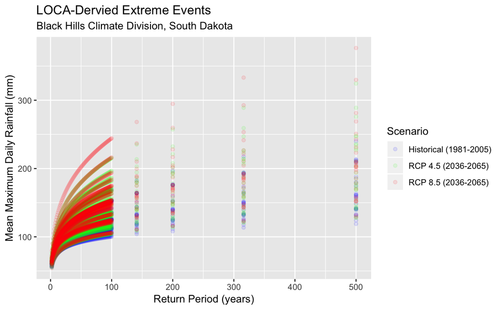

```r
  ggplot(data = return_events) +

    aes(x     = Return_Period,
        y     = Return_Estimate,
        color = Scenario) +

    ggtitle(label    = "LOCA-Dervied Extreme Events",
          subtitle = str_c(Division_Name,
                           " Climate Division, ",
                           State_Name,
                           sep = "")) +

    xlab(label = "Return Period (years)") +
    ylab(label = "Mean Maximum Daily Rainfall (mm)") +
    scale_color_manual(values = c("blue",
                                "green",
                                "red")) +
    geom_point(alpha=.1)
```

```r
NA
NA
NA
```

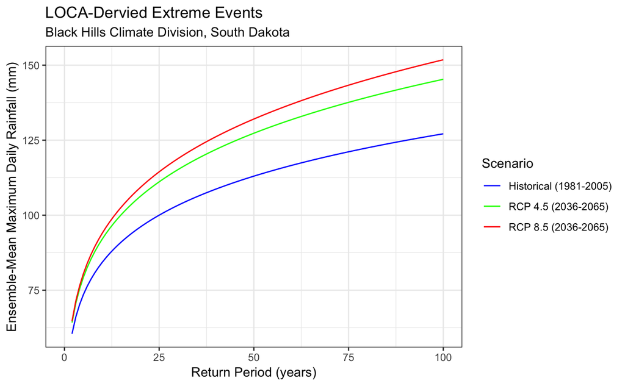

```r
  max_year = 100

  return_events_for_plotting = return_events %>%
                                   filter(Return_Period <= max_year)


  return_events_for_plotting = return_events_for_plotting %>%
                                   group_by(Scenario,
                                            Return_Period) %>%
                                   summarize(Return_Estimate = mean(Return_Estimate))

  ggplot(data = return_events_for_plotting) +

    aes(x     = Return_Period,
        y     = Return_Estimate,
        color = Scenario) +

    theme_bw() +

    ggtitle(label    = "LOCA-Dervied Extreme Events",
          subtitle = str_c(Division_Name,
                           " Climate Division, ",
                           State_Name,
                           sep = "")) +

    xlab(label = "Return Period (years)") +
    ylab(label = "Ensemble-Mean Maximum Daily Rainfall (mm)") +

    xlim(0, max_year) +

    scale_color_manual(values = c("blue",
                                "green",
                                "red")) +

    geom_line()
```

## External Contributed Code: *GeomSplitViolin()*

There are plots where you can see the shape of distributions side-by-side called [“violin plots”](https://en.wikipedia.org/wiki/Violin_plot). Some people like to a pair of distributons. This isn’t officially part of any current R library but it was desirable enough for a air of saints from Max Plank Institute and Stockholm University to write a piece of code to emulate it.

Source: [Stackoverflow](https://stackoverflow.com/questions/35717353/split-violin-plot-with-ggplot2/45614547#45614547)

## Split Violin Plot

Here are the results of those plots comparing the Historical Periods against the Future Periods

Fiorst

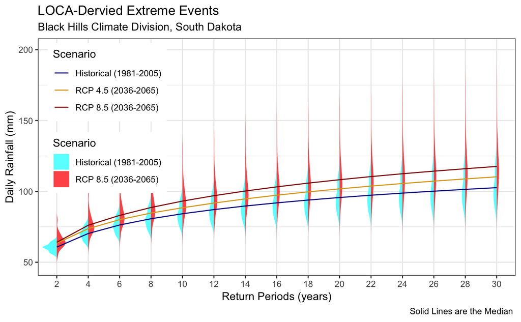

```r
subset = return_events %>% filter(!str_detect(string  =   Scenario,
                                              pattern = "RCP 4.5") &
                                    ((Return_Period %% 2) == 0) &
                                     (Return_Period <= 30))

subset2 = return_events %>%
   filter(     ((Return_Period %% 2) == 0) &
               (Return_Period <= 30)) %>%
  group_by(Scenario,
           Return_Period) %>%
  summarize(Median_Return_Estimate = median(Return_Estimate))

subset$Return_Period = as.factor(subset$Return_Period)
subset2$Return_Period = as.factor(subset2$Return_Period)



  ggplot(data = subset) +

    aes(x     = Return_Period,
        y     = Return_Estimate) +

    theme_bw() +

    theme(legend.position       = c(0.02, 0.98),
          legend.justification  = c(0.00, 1.00)) +

    ggtitle(label    = "LOCA-Dervied Extreme Events",
          subtitle = str_c(Division_Name,
                           " Climate Division, ",
                           State_Name,
                           sep = "")) +

    ylab(label = "Daily Rainfall (mm)") +

    xlab(label = "Return Periods (years)") +
    labs(caption = "Solid Lines are the Median ") +

   scale_fill_manual(values = c( "cyan",  "red")) +


    geom_split_violin(mapping = aes(x    = Return_Period,
                                    y    = Return_Estimate,
                                    fill = Scenario),
                      alpha   = 0.75,
                      trim    = FALSE,
                      color   = NA) +

   scale_colour_manual(values = c( "darkblue", "goldenrod", "darkred")) +



    geom_line(data = subset2,
              mapping = aes(x = Return_Period,
                            y = Median_Return_Estimate,
                            group = Scenario,
                            color = Scenario))
```

```r
    remove(subset, subset2)
```

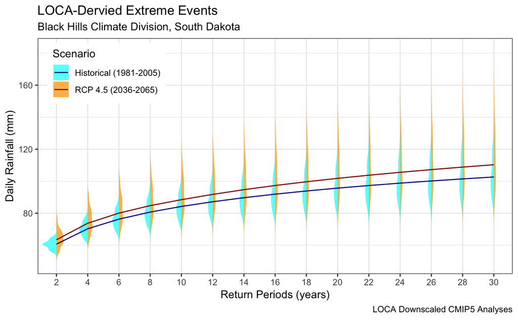

```r
subset = return_events %>% filter(!str_detect(string  =   Scenario,
                                              pattern = "RCP 8.5") &
                                    ((Return_Period %% 2) == 0) &
                                     (Return_Period <= 30))

subset2 = subset %>% group_by(Scenario,
                              Return_Period) %>%
                     summarize(Median_Return_Estimate = median(Return_Estimate))

subset$Return_Period = as.factor(subset$Return_Period)
subset2$Return_Period = as.factor(subset2$Return_Period)

  ggplot(data = subset) +

    aes(x     = Return_Period,
        y     = Return_Estimate) +

    theme_bw() +

    theme(legend.position       = c(0.02, 0.98),
          legend.justification  = c(0.00, 1.00)) +

    ggtitle(label    = "LOCA-Dervied Extreme Events",
          subtitle = str_c(Division_Name,
                           " Climate Division, ",
                           State_Name,
                           sep = "")) +

    ylab(label = "Daily Rainfall (mm)") +

    xlab(label = "Return Periods (years)") +
    labs(caption = "LOCA Downscaled CMIP5 Analyses") +

    scale_fill_manual(values = c( "cyan", "orange"),
                      name  = "Scenario") +

    geom_split_violin(mapping = aes(x    = Return_Period,
                                    y    = Return_Estimate,
                                    fill = Scenario),
                      alpha   = 0.75,
                      trim    = FALSE,
                      color   = NA) +

    scale_colour_manual(values = c( "darkblue", "darkred")) +


    geom_line(data = subset2,
              mapping = aes(x = Return_Period,
                            y = Median_Return_Estimate,
                            group = Scenario,
                            color = Scenario))
```

```r
    remove(subset, subset2)
```